# STAT364 Data Science Problems with the Error, Transformation, Model Selection, & Shrinkage Methods Homework 4

Kira Novitchkova-Burbank

# Chapter 8 Problem 1:

### Researchers at National Institutes of Standards and Technology (NIST) collected pipeline data on ultrasonic measurements of the depth of defects in the Alaska pipeline in the field. The depth of the defects were then remeasured in the laboratory. These measurements were performed in six different batches. It turns out that this batch effect is not significant and so can be ignored in the analysis that follows. The laboratory measurements are more accurate than the in-field measurements, but more time consuming and expensive. We want to develop a regression equation for correcting the in-field measurements.

### (a) Fit a regression model Lab ~ Field. Check for non-constant variance.

```r
library(faraway)
data(pipeline, package = "faraway")
summary(pipeline)
```

```
##      Field            Lab        Batch
##  Min.   : 5.00   Min.   : 4.30   1:19
##  1st Qu.:18.00   1st Qu.:18.35   2:20
##  Median :35.00   Median :38.00   3:20
##  Mean   :33.58   Mean   :39.10   4:20
##  3rd Qu.:46.50   3rd Qu.:55.55   5:21
##  Max.   :85.00   Max.   :81.90   6: 7
```

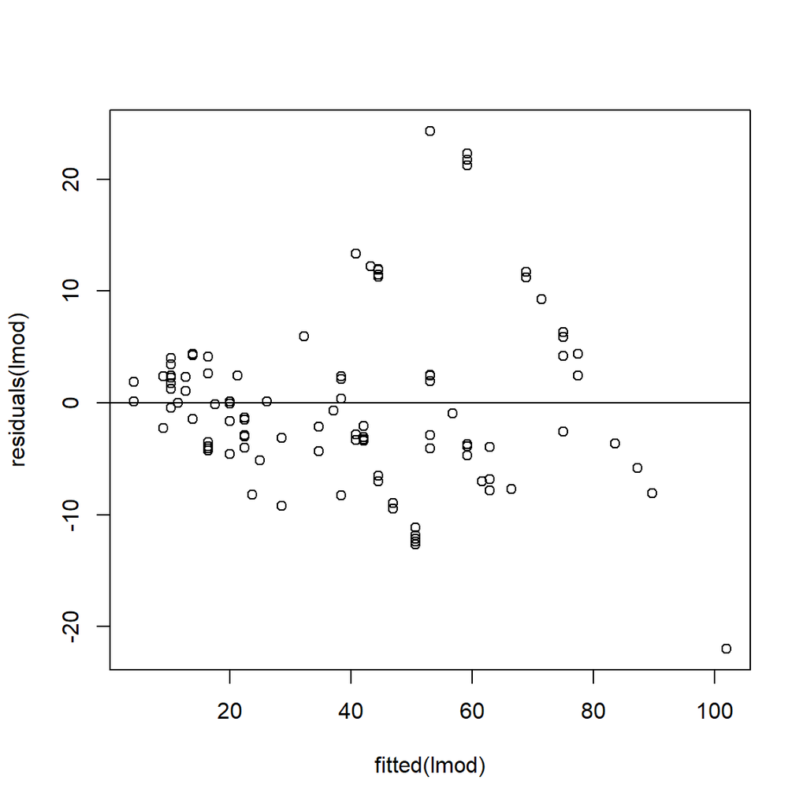

```r
#residual vs fitted plot to check non constant variance
lmod <- lm(Lab ~ Field, data = pipeline)
plot(fitted(lmod), residuals(lmod))
abline(h=0)
```

**Your answer:** Based on this residual vs fitted plot, it seems like there is a small pattern so the variance is non-constant.

### (b) We wish to use weights to account for the non-constant variance. Here we split the range of Field into 12 groups of size nine (except for the last group which has only eight values). Within each group, we compute the variance of Lab as varlab and the mean of Field as meanfield. Supposing pipeline is the name of your data frame, the following R code will make the needed computations:

### Code from textbook (code chunk below)

```r
#code from textbook: Here we split the range of Field into 12 groups of size nine (except for the last group which has only eight values). Within each group, we compute the variance of Lab as varlab and the mean of Field as meanfield.

i <- order(pipeline$Field)
npipe <- pipeline[i,]
ff <- gl(12,9)[-108]
meanfield <- unlist(lapply(split(npipe$Field, ff), mean))
varlab <- unlist(lapply(split(npipe$Lab, ff), var))
```

### Suppose we guess that the the variance in the response is linked to the predictor in the following way:

### Equation from book (is something like this var(Lab)=a0Field^(a1))

### Regress log(varlab) on log(meanfield) to estimate a0 and a1. (You might choose to remove the last point.) Use this to determine appropriate weights in a WLS fit of Lab on Field. Show the regression summary.

```r
#First create a data frame
#Then Regress y on x so log(varlab) ~ log(meanfield)

pipeline_varlab_meanfield_df <- data.frame(log_varlab = log(varlab), log_meanfield = log(meanfield))

#determining weights
#weight = 1/sqrt(varlab)

pipeline_varlab_meanfield_lmod <- lm(log_varlab ~ log_meanfield, data = pipeline_varlab_meanfield_df, weights = 1/sqrt(varlab))

summary(pipeline_varlab_meanfield_lmod)
```

```
##
## Call:
## lm(formula = log_varlab ~ log_meanfield, data = pipeline_varlab_meanfield_df,
##     weights = 1/sqrt(varlab))
##
## Weighted Residuals:
##     Min      1Q  Median      3Q     Max
## -0.7118 -0.1478  0.1142  0.4427  0.5317
##
## Coefficients:
##               Estimate Std. Error t value Pr(>|t|)
## (Intercept)     1.0420     1.2905   0.807    0.438
## log_meanfield   0.5686     0.3992   1.424    0.185
##
## Residual standard error: 0.4216 on 10 degrees of freedom
## Multiple R-squared:  0.1687, Adjusted R-squared:  0.08552
## F-statistic: 2.029 on 1 and 10 DF,  p-value: 0.1848
```

### (c) An alternative to weighting is transformation. Find transformations on Lab and/or Field so that in the transformed scale the relationship is approximately linear with constant variance. You may restrict your choice of transformation to square root, log and inverse.

Trying different transformations: sqrt both Lab and Field

```r
#install.packages("matlib")

library(matlib)
```

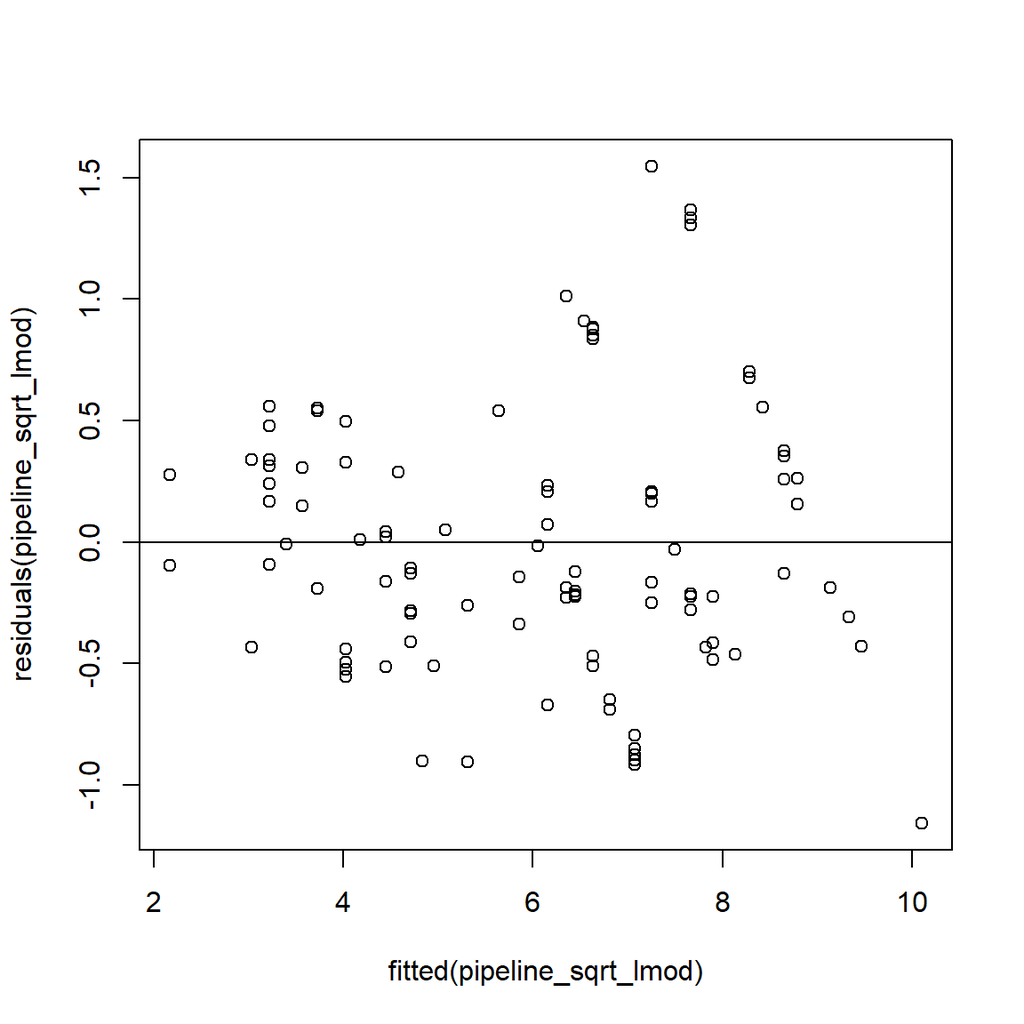

```r
pipeline_sqrt_df <- data.frame(sqrt_Lab = sqrt(pipeline$Lab), sqrt_Field = sqrt(pipeline$Field))
pipeline_sqrt_lmod <- lm(sqrt_Lab ~ sqrt_Field, data = pipeline_sqrt_df)

##residual vs fitted plot to check non constant variance
plot(fitted(pipeline_sqrt_lmod), residuals(pipeline_sqrt_lmod))
abline(h=0)
```

**Your answer:** Based on this plot, it seems like there is non-constant variance.

Trying different transformations: log both Lab and Field

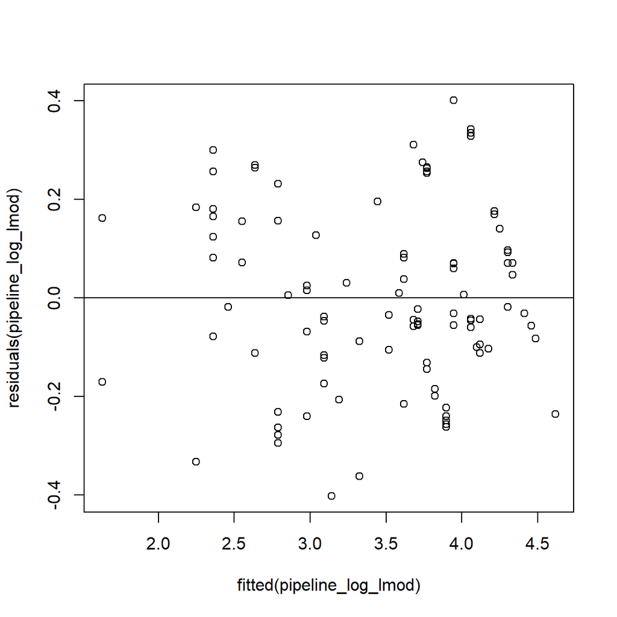

```r
library(matlib)
pipeline_log_df <- data.frame(log_Lab = log(pipeline$Lab), log_Field = log(pipeline$Field))
pipeline_log_lmod <- lm(log_Lab ~ log_Field, data = pipeline_log_df)

##residual vs fitted plot to check non constant variance
plot(fitted(pipeline_log_lmod), residuals(pipeline_log_lmod))
abline(h=0)
```

**Your answer:** Based on this plot, it seems like the variance is almost constant.

Trying different transformations: inverse both Lab and Field

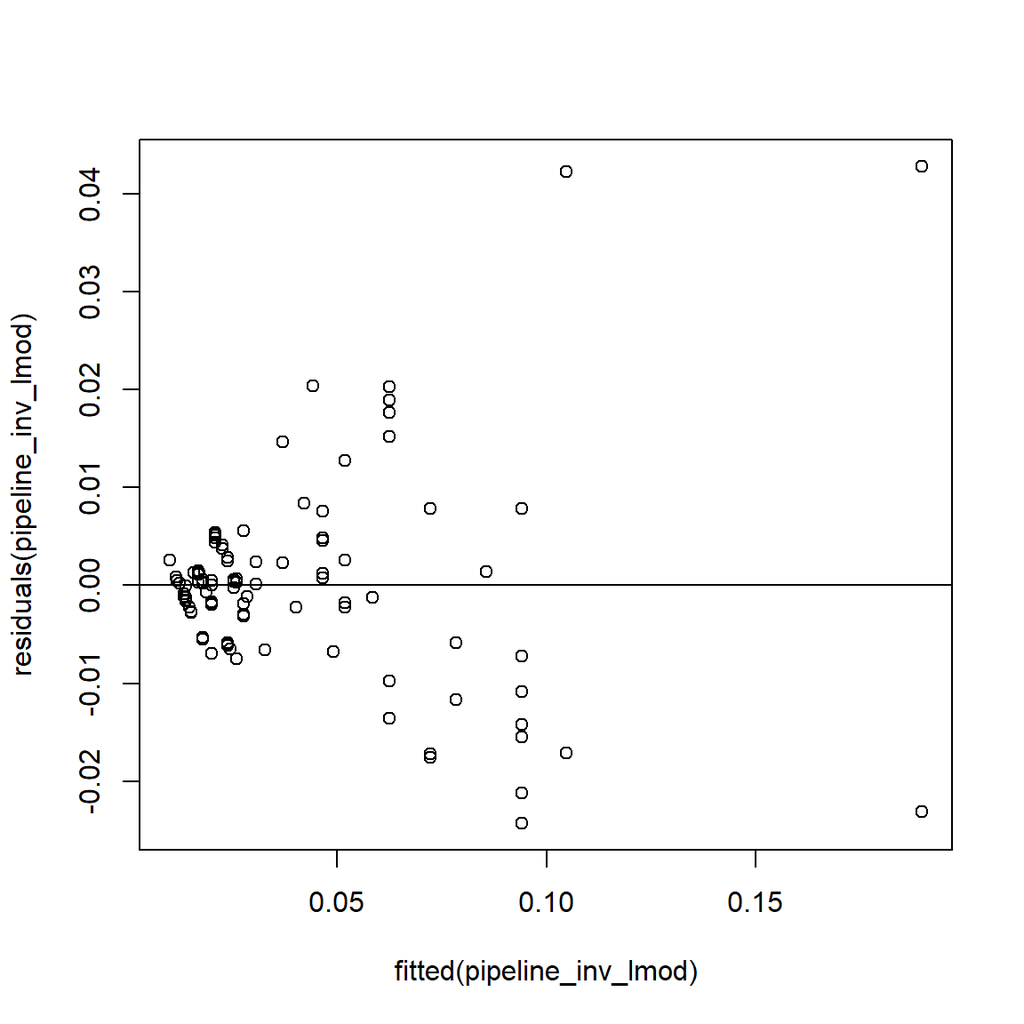

```r
library(matlib)
pipeline_inv_df <- data.frame(inv_Lab = 1/(pipeline$Lab), inv_Field = 1/(pipeline$Field))
pipeline_inv_lmod <- lm(inv_Lab ~ inv_Field, data = pipeline_inv_df)

##residual vs fitted plot to check non constant variance
plot(fitted(pipeline_inv_lmod), residuals(pipeline_inv_lmod))
abline(h=0)
```

**Your answer:** Based on this plot, it seems like there is non-constant variance.

Trying different transformations: sqrt only Lab

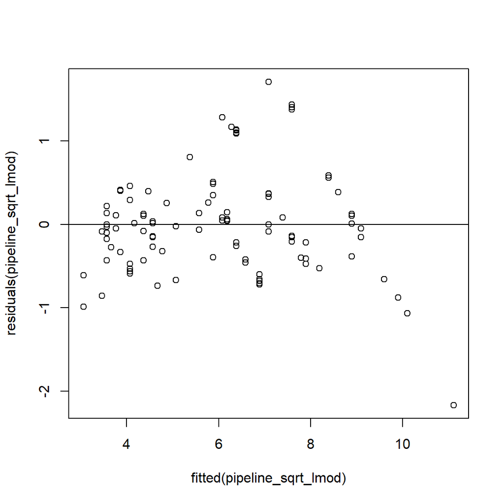

```r
library(matlib)
pipeline_sqrt_df <- data.frame(sqrt_Lab = sqrt(pipeline$Lab), Field = pipeline$Field)
pipeline_sqrt_lmod <- lm(sqrt_Lab ~ Field, data = pipeline_sqrt_df)

##residual vs fitted plot to check non constant variance
plot(fitted(pipeline_sqrt_lmod), residuals(pipeline_sqrt_lmod))
abline(h=0)
```

**Your answer:** Based on this plot, it seems like there is non-constant variance.

Trying different transformations: sqrt only Field

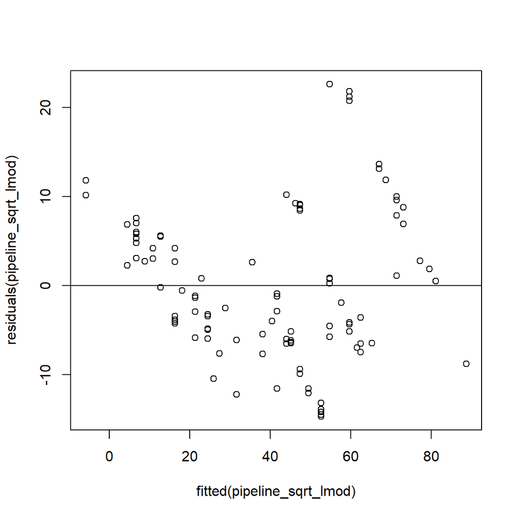

```r
library(matlib)
pipeline_sqrt_df <- data.frame(Lab = pipeline$Lab, sqrt_Field = sqrt(pipeline$Field))
pipeline_sqrt_lmod <- lm(Lab ~ sqrt_Field, data = pipeline_sqrt_df)

##residual vs fitted plot to check non constant variance
plot(fitted(pipeline_sqrt_lmod), residuals(pipeline_sqrt_lmod))
abline(h=0)
```

**Your answer:** Based on this plot, it seems like there is non-constant variance.

Trying different transformations: log only Lab

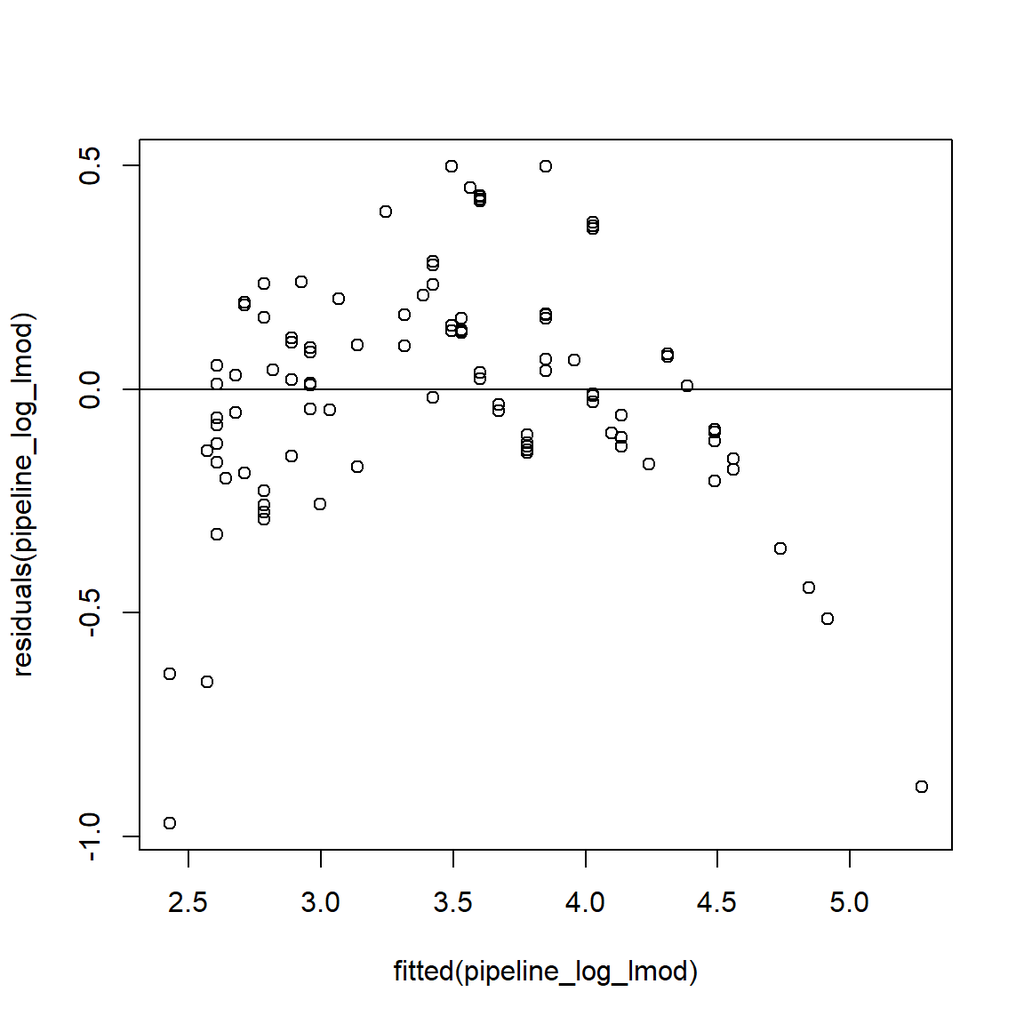

```r
library(matlib)
pipeline_log_df <- data.frame(log_Lab = log(pipeline$Lab), Field = pipeline$Field)
pipeline_log_lmod <- lm(log_Lab ~ Field, data = pipeline_log_df)

##residual vs fitted plot to check non constant variance
plot(fitted(pipeline_log_lmod), residuals(pipeline_log_lmod))
abline(h=0)
```

**Your answer:** Based on this plot, it seems like there is non-constant variance.

Trying different transformations: log only Field

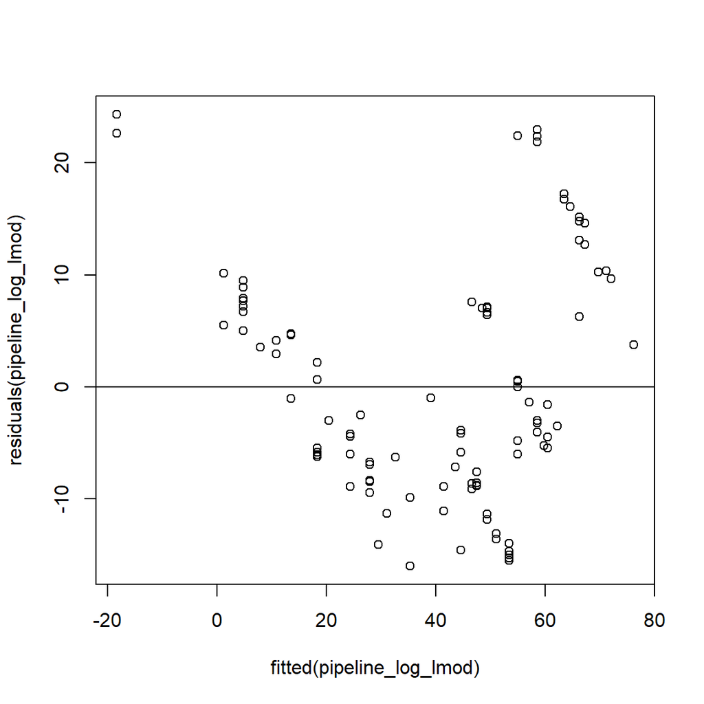

```r
library(matlib)
pipeline_log_df <- data.frame(Lab = pipeline$Lab, log_Field = log(pipeline$Field))
pipeline_log_lmod <- lm(Lab ~ log_Field, data = pipeline_log_df)

##residual vs fitted plot to check non constant variance
plot(fitted(pipeline_log_lmod), residuals(pipeline_log_lmod))
abline(h=0)
```

**Your answer:** Based on this plot, it seems like there is non-constant variance.

Trying different transformations: inverse only Lab

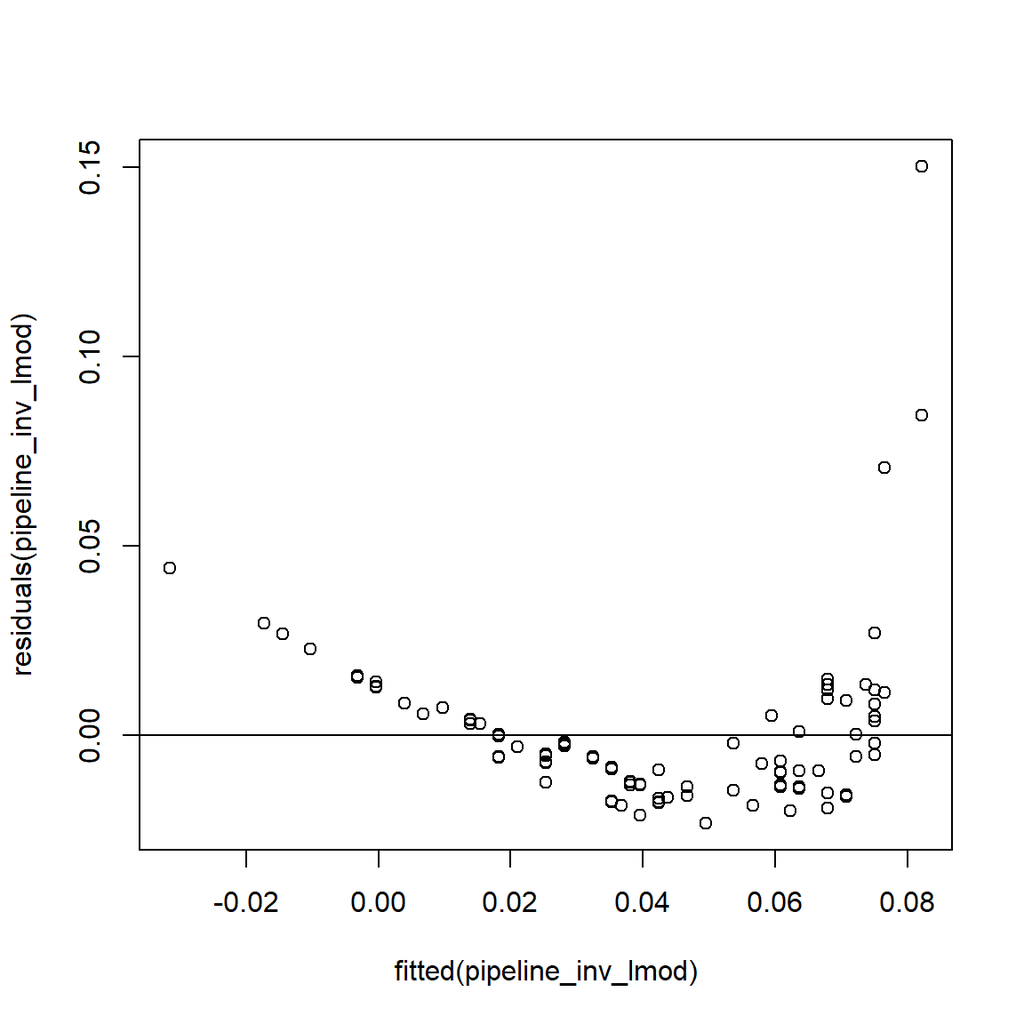

```r
library(matlib)
pipeline_inv_df <- data.frame(inv_Lab = 1/(pipeline$Lab), Field = pipeline$Field)
pipeline_inv_lmod <- lm(inv_Lab ~ Field, data = pipeline_inv_df)

##residual vs fitted plot to check non constant variance
plot(fitted(pipeline_inv_lmod), residuals(pipeline_inv_lmod))
abline(h=0)
```

**Your answer:** Based on this plot, it seems like there is non-constant variance.

Trying different transformations: inverse only Field

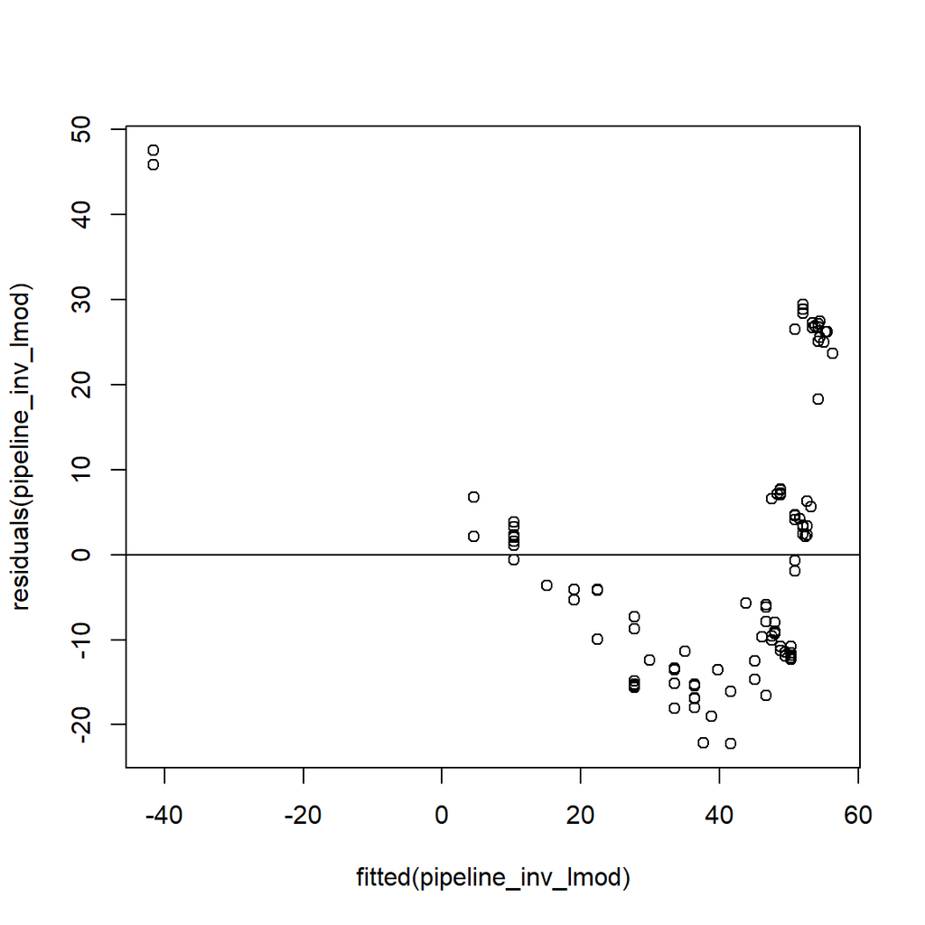

```r
library(matlib)
pipeline_inv_df <- data.frame(Lab = pipeline$Lab, inv_Field = 1/(pipeline$Field))
pipeline_inv_lmod <- lm(Lab ~ inv_Field, data = pipeline_inv_df)

##residual vs fitted plot to check non constant variance
plot(fitted(pipeline_inv_lmod), residuals(pipeline_inv_lmod))
abline(h=0)
```

**Your answer:** Based on this plot, it seems like there is non-constant variance.

**Your answer:** Out of all of these plots of the transformations, the plot with log of both Lab and Field had the most constant variance. So, it seems like that is the best transformation.

# Chapter 9 Problem 3

### Using the ozone data, fit a model with O3 as the response and temp, humidity and ibh as predictors. Use the Box–Cox method to determine the best transformation on the response.

```r
library(faraway)
data(ozone, package = "faraway")
summary(ozone)
```

```
##        O3              vh            wind           humidity
##  Min.   : 1.00   Min.   :5320   Min.   : 0.000   Min.   :19.00
##  1st Qu.: 5.00   1st Qu.:5690   1st Qu.: 3.000   1st Qu.:47.00
##  Median :10.00   Median :5760   Median : 5.000   Median :64.00
##  Mean   :11.78   Mean   :5750   Mean   : 4.848   Mean   :58.13
##  3rd Qu.:17.00   3rd Qu.:5830   3rd Qu.: 6.000   3rd Qu.:73.00
##  Max.   :38.00   Max.   :5950   Max.   :11.000   Max.   :93.00
##       temp            ibh              dpg              ibt
##  Min.   :25.00   Min.   : 111.0   Min.   :-69.00   Min.   :-25.0
##  1st Qu.:51.00   1st Qu.: 877.5   1st Qu.: -9.00   1st Qu.:107.0
##  Median :62.00   Median :2112.5   Median : 24.00   Median :167.5
##  Mean   :61.75   Mean   :2572.9   Mean   : 17.37   Mean   :161.2
##  3rd Qu.:72.00   3rd Qu.:5000.0   3rd Qu.: 44.75   3rd Qu.:214.0
##  Max.   :93.00   Max.   :5000.0   Max.   :107.00   Max.   :332.0
##       vis             doy
##  Min.   :  0.0   Min.   : 33.0
##  1st Qu.: 70.0   1st Qu.:120.2
##  Median :120.0   Median :205.5
##  Mean   :124.5   Mean   :209.4
##  3rd Qu.:150.0   3rd Qu.:301.8
##  Max.   :350.0   Max.   :390.0
```

```r
lmod <- lm(O3 ~ temp + humidity + ibh, data = ozone)
summary(lmod)
```

```
##
## Call:
## lm(formula = O3 ~ temp + humidity + ibh, data = ozone)
##
## Residuals:
##      Min       1Q   Median       3Q      Max
## -11.5291  -3.0137  -0.2249   2.8239  13.9303
##
## Coefficients:
##               Estimate Std. Error t value Pr(>|t|)
## (Intercept) -1.049e+01  1.616e+00  -6.492 3.16e-10 ***
## temp         3.296e-01  2.109e-02  15.626  < 2e-16 ***
## humidity     7.738e-02  1.339e-02   5.777 1.77e-08 ***
## ibh         -1.004e-03  1.639e-04  -6.130 2.54e-09 ***
## ---
## Signif. codes:  0 '***' 0.001 '**' 0.01 '*' 0.05 '.' 0.1 ' ' 1
##
## Residual standard error: 4.524 on 326 degrees of freedom
## Multiple R-squared:  0.684,  Adjusted R-squared:  0.6811
## F-statistic: 235.2 on 3 and 326 DF,  p-value: < 2.2e-16
```

**Your answer:** The R^2 value is 0.684. That means that 68.4% of the variance of the response is explained by the predictors before the boxcox transformation.

```r
#install.packages("MASS")
library(MASS)
```

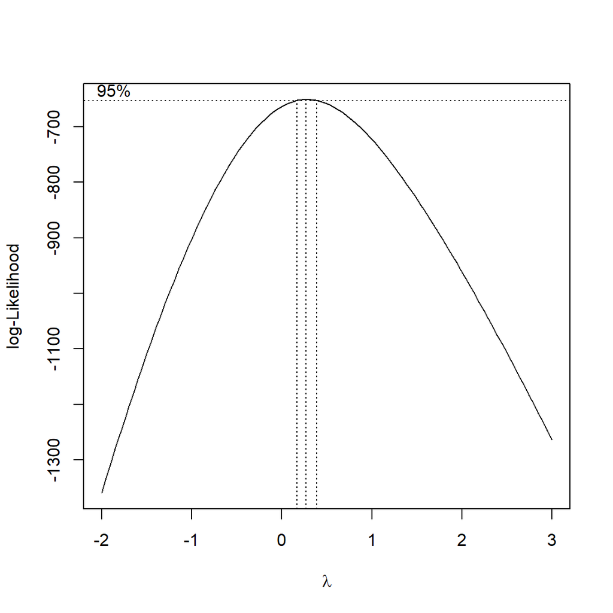

```r
box_cox <- boxcox(lmod, lambda = seq(-2, 3, by=0.1)) #lambdas by default were from -2 to 2 but the graph didn't look as good that's why lambdas are now -2 to 3
```

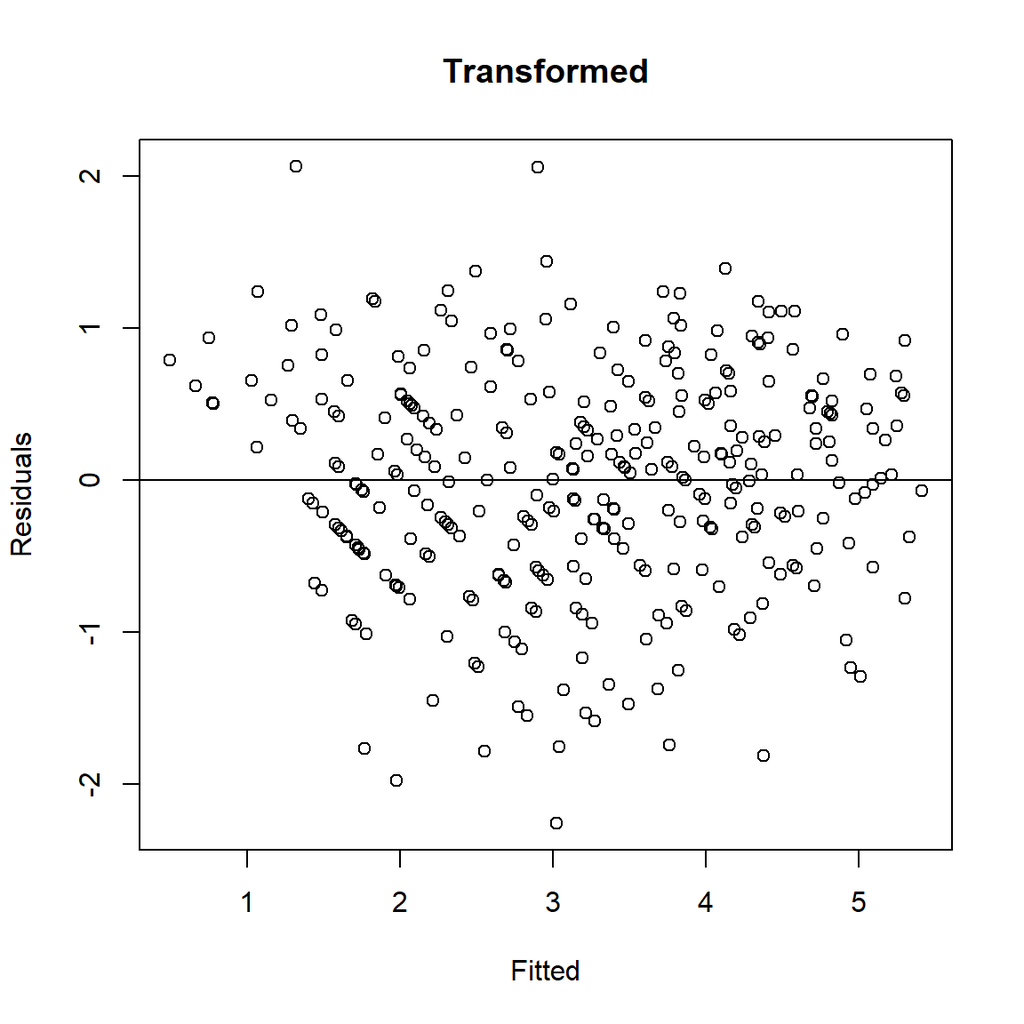

```r
#best lambda
lambda <- box_cox$x[which.max(box_cox$y)]
ozone$ystar <- (ozone$O3^lambda-1)/lambda

#plotting transformed lmod
lmod_ystar <- lm(ystar ~ temp + humidity + ibh, data = ozone)
plot(fitted(lmod_ystar), residuals(lmod_ystar), xlab="Fitted", ylab="Residuals", main = "Transformed")
abline(h=0)
```

```r
summary(lmod_ystar)
```

```
##
## Call:
## lm(formula = ystar ~ temp + humidity + ibh, data = ozone)
##
## Residuals:
##      Min       1Q   Median       3Q      Max
## -2.25617 -0.44974  0.03727  0.52010  2.06666
##
## Coefficients:
##               Estimate Std. Error t value Pr(>|t|)
## (Intercept) -4.360e-01  2.600e-01  -1.677   0.0945 .
## temp         5.510e-02  3.393e-03  16.238  < 2e-16 ***
## humidity     1.260e-02  2.155e-03   5.847 1.21e-08 ***
## ibh         -2.033e-04  2.636e-05  -7.713 1.50e-13 ***
## ---
## Signif. codes:  0 '***' 0.001 '**' 0.01 '*' 0.05 '.' 0.1 ' ' 1
##
## Residual standard error: 0.7278 on 326 degrees of freedom
## Multiple R-squared:  0.716,  Adjusted R-squared:  0.7134
## F-statistic:   274 on 3 and 326 DF,  p-value: < 2.2e-16
```

**Your answer:** The R^2 value increased to 0.716 after the boxcox transformation. That means that 71.6% of the variance of the response is explained by the predictors after the boxcox transformation.

# Chapter 10 Problem 1

## Use the prostate data with lpsa as the response and the other variables as predictors. Implement the following variable selection methods to determine the “best” model: (a) Backward elimination

```r
library(faraway)
data(prostate, package = "faraway")
summary(prostate)
```

```
##      lcavol           lweight           age             lbph
##  Min.   :-1.3471   Min.   :2.375   Min.   :41.00   Min.   :-1.3863
##  1st Qu.: 0.5128   1st Qu.:3.376   1st Qu.:60.00   1st Qu.:-1.3863
##  Median : 1.4469   Median :3.623   Median :65.00   Median : 0.3001
##  Mean   : 1.3500   Mean   :3.653   Mean   :63.87   Mean   : 0.1004
##  3rd Qu.: 2.1270   3rd Qu.:3.878   3rd Qu.:68.00   3rd Qu.: 1.5581
##  Max.   : 3.8210   Max.   :6.108   Max.   :79.00   Max.   : 2.3263
##       svi              lcp             gleason          pgg45
##  Min.   :0.0000   Min.   :-1.3863   Min.   :6.000   Min.   :  0.00
##  1st Qu.:0.0000   1st Qu.:-1.3863   1st Qu.:6.000   1st Qu.:  0.00
##  Median :0.0000   Median :-0.7985   Median :7.000   Median : 15.00
##  Mean   :0.2165   Mean   :-0.1794   Mean   :6.753   Mean   : 24.38
##  3rd Qu.:0.0000   3rd Qu.: 1.1786   3rd Qu.:7.000   3rd Qu.: 40.00
##  Max.   :1.0000   Max.   : 2.9042   Max.   :9.000   Max.   :100.00
##       lpsa
##  Min.   :-0.4308
##  1st Qu.: 1.7317
##  Median : 2.5915
##  Mean   : 2.4784
##  3rd Qu.: 3.0564
##  Max.   : 5.5829
```

```r
lmod <- lm(lpsa ~., data = prostate)
summary(lmod)
```

```
##
## Call:
## lm(formula = lpsa ~ ., data = prostate)
##
## Residuals:
##     Min      1Q  Median      3Q     Max
## -1.7331 -0.3713 -0.0170  0.4141  1.6381
##
## Coefficients:
##              Estimate Std. Error t value Pr(>|t|)
## (Intercept)  0.669337   1.296387   0.516  0.60693
## lcavol       0.587022   0.087920   6.677 2.11e-09 ***
## lweight      0.454467   0.170012   2.673  0.00896 **
## age         -0.019637   0.011173  -1.758  0.08229 .
## lbph         0.107054   0.058449   1.832  0.07040 .
## svi          0.766157   0.244309   3.136  0.00233 **
## lcp         -0.105474   0.091013  -1.159  0.24964
## gleason      0.045142   0.157465   0.287  0.77503
## pgg45        0.004525   0.004421   1.024  0.30886
## ---
## Signif. codes:  0 '***' 0.001 '**' 0.01 '*' 0.05 '.' 0.1 ' ' 1
##
## Residual standard error: 0.7084 on 88 degrees of freedom
## Multiple R-squared:  0.6548, Adjusted R-squared:  0.6234
## F-statistic: 20.86 on 8 and 88 DF,  p-value: < 2.2e-16
```

**Your answer:** Remove the predictor with the highest p-value. In this case, the predictor is gleason with a p-value of 0.77503. Then, fit the model again without it.

Fit the model without gleason:

```r
lmod <- update(lmod, . ~ . - gleason)
summary(lmod)
```

```
##
## Call:
## lm(formula = lpsa ~ lcavol + lweight + age + lbph + svi + lcp +
##     pgg45, data = prostate)
##
## Residuals:
##      Min       1Q   Median       3Q      Max
## -1.73117 -0.38137 -0.01728  0.43364  1.63513
##
## Coefficients:
##              Estimate Std. Error t value Pr(>|t|)
## (Intercept)  0.953926   0.829439   1.150  0.25319
## lcavol       0.591615   0.086001   6.879 8.07e-10 ***
## lweight      0.448292   0.167771   2.672  0.00897 **
## age         -0.019336   0.011066  -1.747  0.08402 .
## lbph         0.107671   0.058108   1.853  0.06720 .
## svi          0.757734   0.241282   3.140  0.00229 **
## lcp         -0.104482   0.090478  -1.155  0.25127
## pgg45        0.005318   0.003433   1.549  0.12488
## ---
## Signif. codes:  0 '***' 0.001 '**' 0.01 '*' 0.05 '.' 0.1 ' ' 1
##
## Residual standard error: 0.7048 on 89 degrees of freedom
## Multiple R-squared:  0.6544, Adjusted R-squared:  0.6273
## F-statistic: 24.08 on 7 and 89 DF,  p-value: < 2.2e-16
```

**Your answer:** Remove the predictor with the highest p-value. In this case, the predictor is lcp with a p-value of 0.25127. Then, fit the model again without it.

Fit the model without lcp:

```r
lmod <- update(lmod, . ~ . - lcp)
summary(lmod)
```

```
##
## Call:
## lm(formula = lpsa ~ lcavol + lweight + age + lbph + svi + pgg45,
##     data = prostate)
##
## Residuals:
##      Min       1Q   Median       3Q      Max
## -1.77711 -0.41708  0.00002  0.40676  1.59681
##
## Coefficients:
##              Estimate Std. Error t value Pr(>|t|)
## (Intercept)  0.980085   0.830665   1.180  0.24116
## lcavol       0.545770   0.076431   7.141 2.31e-10 ***
## lweight      0.449450   0.168078   2.674  0.00890 **
## age         -0.017470   0.010967  -1.593  0.11469
## lbph         0.105755   0.058191   1.817  0.07249 .
## svi          0.641666   0.219757   2.920  0.00442 **
## pgg45        0.003528   0.003068   1.150  0.25331
## ---
## Signif. codes:  0 '***' 0.001 '**' 0.01 '*' 0.05 '.' 0.1 ' ' 1
##
## Residual standard error: 0.7061 on 90 degrees of freedom
## Multiple R-squared:  0.6493, Adjusted R-squared:  0.6259
## F-statistic: 27.77 on 6 and 90 DF,  p-value: < 2.2e-16
```

**Your answer:** Remove the predictor with the highest p-value. In this case, the predictor is pgg45 with a p-value of 0.25331. Then, fit the model again without it.

Fit the model without pgg45:

```r
lmod <- update(lmod, . ~ . - pgg45)
summary(lmod)
```

```
##
## Call:
## lm(formula = lpsa ~ lcavol + lweight + age + lbph + svi, data = prostate)
##
## Residuals:
##      Min       1Q   Median       3Q      Max
## -1.83505 -0.39396  0.00414  0.46336  1.57888
##
## Coefficients:
##             Estimate Std. Error t value Pr(>|t|)
## (Intercept)  0.95100    0.83175   1.143 0.255882
## lcavol       0.56561    0.07459   7.583 2.77e-11 ***
## lweight      0.42369    0.16687   2.539 0.012814 *
## age         -0.01489    0.01075  -1.385 0.169528
## lbph         0.11184    0.05805   1.927 0.057160 .
## svi          0.72095    0.20902   3.449 0.000854 ***
## ---
## Signif. codes:  0 '***' 0.001 '**' 0.01 '*' 0.05 '.' 0.1 ' ' 1
##
## Residual standard error: 0.7073 on 91 degrees of freedom
## Multiple R-squared:  0.6441, Adjusted R-squared:  0.6245
## F-statistic: 32.94 on 5 and 91 DF,  p-value: < 2.2e-16
```

**Your answer:** Remove the predictor with the highest p-value. In this case, the predictor is age with a p-value of 0.169528. Then, fit the model again without it.

Fit the model without age:

```r
lmod <- update(lmod, . ~ . - age)
summary(lmod)
```

```
##
## Call:
## lm(formula = lpsa ~ lcavol + lweight + lbph + svi, data = prostate)
##
## Residuals:
##      Min       1Q   Median       3Q      Max
## -1.82653 -0.42270  0.04362  0.47041  1.48530
##
## Coefficients:
##             Estimate Std. Error t value Pr(>|t|)
## (Intercept)  0.14554    0.59747   0.244  0.80809
## lcavol       0.54960    0.07406   7.422 5.64e-11 ***
## lweight      0.39088    0.16600   2.355  0.02067 *
## lbph         0.09009    0.05617   1.604  0.11213
## svi          0.71174    0.20996   3.390  0.00103 **
## ---
## Signif. codes:  0 '***' 0.001 '**' 0.01 '*' 0.05 '.' 0.1 ' ' 1
##
## Residual standard error: 0.7108 on 92 degrees of freedom
## Multiple R-squared:  0.6366, Adjusted R-squared:  0.6208
## F-statistic: 40.29 on 4 and 92 DF,  p-value: < 2.2e-16
```

**Your answer:** Remove the predictor with the highest p-value. In this case, the predictor is lbph with a p-value of 0.11213. Then, fit the model again without it.

Fit the model without lbph:

```r
lmod <- update(lmod, . ~ . - lbph)
summary(lmod)
```

```
##
## Call:
## lm(formula = lpsa ~ lcavol + lweight + svi, data = prostate)
##
## Residuals:
##      Min       1Q   Median       3Q      Max
## -1.72964 -0.45764  0.02812  0.46403  1.57013
##
## Coefficients:
##             Estimate Std. Error t value Pr(>|t|)
## (Intercept) -0.26809    0.54350  -0.493  0.62298
## lcavol       0.55164    0.07467   7.388  6.3e-11 ***
## lweight      0.50854    0.15017   3.386  0.00104 **
## svi          0.66616    0.20978   3.176  0.00203 **
## ---
## Signif. codes:  0 '***' 0.001 '**' 0.01 '*' 0.05 '.' 0.1 ' ' 1
##
## Residual standard error: 0.7168 on 93 degrees of freedom
## Multiple R-squared:  0.6264, Adjusted R-squared:  0.6144
## F-statistic: 51.99 on 3 and 93 DF,  p-value: < 2.2e-16
```

**Your answer:** None of the predictors have non significant p-values (p-values > 0.05). So, you don’t remove anymore predictors because this is the best model based on backward elimination. So, the best model has the 3 predictors that are lcavol, lweight, and svi.

## (b) AIC

```r
summary(step(lm(lpsa ~ ., data = prostate), direction="backward"))
```

```
## Start:  AIC=-58.32
## lpsa ~ lcavol + lweight + age + lbph + svi + lcp + gleason +
##     pgg45
##
##           Df Sum of Sq    RSS     AIC
## - gleason  1    0.0412 44.204 -60.231
## - pgg45    1    0.5258 44.689 -59.174
## - lcp      1    0.6740 44.837 -58.853
## <none>                 44.163 -58.322
## - age      1    1.5503 45.713 -56.975
## - lbph     1    1.6835 45.847 -56.693
## - lweight  1    3.5861 47.749 -52.749
## - svi      1    4.9355 49.099 -50.046
## - lcavol   1   22.3721 66.535 -20.567
##
## Step:  AIC=-60.23
## lpsa ~ lcavol + lweight + age + lbph + svi + lcp + pgg45
##
##           Df Sum of Sq    RSS     AIC
## - lcp      1    0.6623 44.867 -60.789
## <none>                 44.204 -60.231
## - pgg45    1    1.1920 45.396 -59.650
## - age      1    1.5166 45.721 -58.959
## - lbph     1    1.7053 45.910 -58.560
## - lweight  1    3.5462 47.750 -54.746
## - svi      1    4.8984 49.103 -52.037
## - lcavol   1   23.5039 67.708 -20.872
##
## Step:  AIC=-60.79
## lpsa ~ lcavol + lweight + age + lbph + svi + pgg45
##
##           Df Sum of Sq    RSS     AIC
## - pgg45    1    0.6590 45.526 -61.374
## <none>                 44.867 -60.789
## - age      1    1.2649 46.131 -60.092
## - lbph     1    1.6465 46.513 -59.293
## - lweight  1    3.5647 48.431 -55.373
## - svi      1    4.2503 49.117 -54.009
## - lcavol   1   25.4189 70.285 -19.248
##
## Step:  AIC=-61.37
## lpsa ~ lcavol + lweight + age + lbph + svi
##
##           Df Sum of Sq    RSS     AIC
## <none>                 45.526 -61.374
## - age      1    0.9592 46.485 -61.352
## - lbph     1    1.8568 47.382 -59.497
## - lweight  1    3.2251 48.751 -56.735
## - svi      1    5.9517 51.477 -51.456
## - lcavol   1   28.7665 74.292 -15.871
```

```
##
## Call:
## lm(formula = lpsa ~ lcavol + lweight + age + lbph + svi, data = prostate)
##
## Residuals:
##      Min       1Q   Median       3Q      Max
## -1.83505 -0.39396  0.00414  0.46336  1.57888
##
## Coefficients:
##             Estimate Std. Error t value Pr(>|t|)
## (Intercept)  0.95100    0.83175   1.143 0.255882
## lcavol       0.56561    0.07459   7.583 2.77e-11 ***
## lweight      0.42369    0.16687   2.539 0.012814 *
## age         -0.01489    0.01075  -1.385 0.169528
## lbph         0.11184    0.05805   1.927 0.057160 .
## svi          0.72095    0.20902   3.449 0.000854 ***
## ---
## Signif. codes:  0 '***' 0.001 '**' 0.01 '*' 0.05 '.' 0.1 ' ' 1
##
## Residual standard error: 0.7073 on 91 degrees of freedom
## Multiple R-squared:  0.6441, Adjusted R-squared:  0.6245
## F-statistic: 32.94 on 5 and 91 DF,  p-value: < 2.2e-16
```

**Your answer:** Based on AIC, the best model has the 5 predictors lcavol, lweight, age, lbph, and svi.

## (c) Adjusted R2

```r
#install.packages("leaps")
library(leaps)
b <- regsubsets(lpsa ~ ., data = prostate)
rs <- summary(b)
rs$which
```

```
##   (Intercept) lcavol lweight   age  lbph   svi   lcp gleason pgg45
## 1        TRUE   TRUE   FALSE FALSE FALSE FALSE FALSE   FALSE FALSE
## 2        TRUE   TRUE    TRUE FALSE FALSE FALSE FALSE   FALSE FALSE
## 3        TRUE   TRUE    TRUE FALSE FALSE  TRUE FALSE   FALSE FALSE
## 4        TRUE   TRUE    TRUE FALSE  TRUE  TRUE FALSE   FALSE FALSE
## 5        TRUE   TRUE    TRUE  TRUE  TRUE  TRUE FALSE   FALSE FALSE
## 6        TRUE   TRUE    TRUE  TRUE  TRUE  TRUE FALSE   FALSE  TRUE
## 7        TRUE   TRUE    TRUE  TRUE  TRUE  TRUE  TRUE   FALSE  TRUE
## 8        TRUE   TRUE    TRUE  TRUE  TRUE  TRUE  TRUE    TRUE  TRUE
```

```r
#Adjusted R^2 values
rs$adjr2
```

```
## [1] 0.5345838 0.5771246 0.6143899 0.6208036 0.6245476 0.6258707 0.6272521
## [8] 0.6233681
```

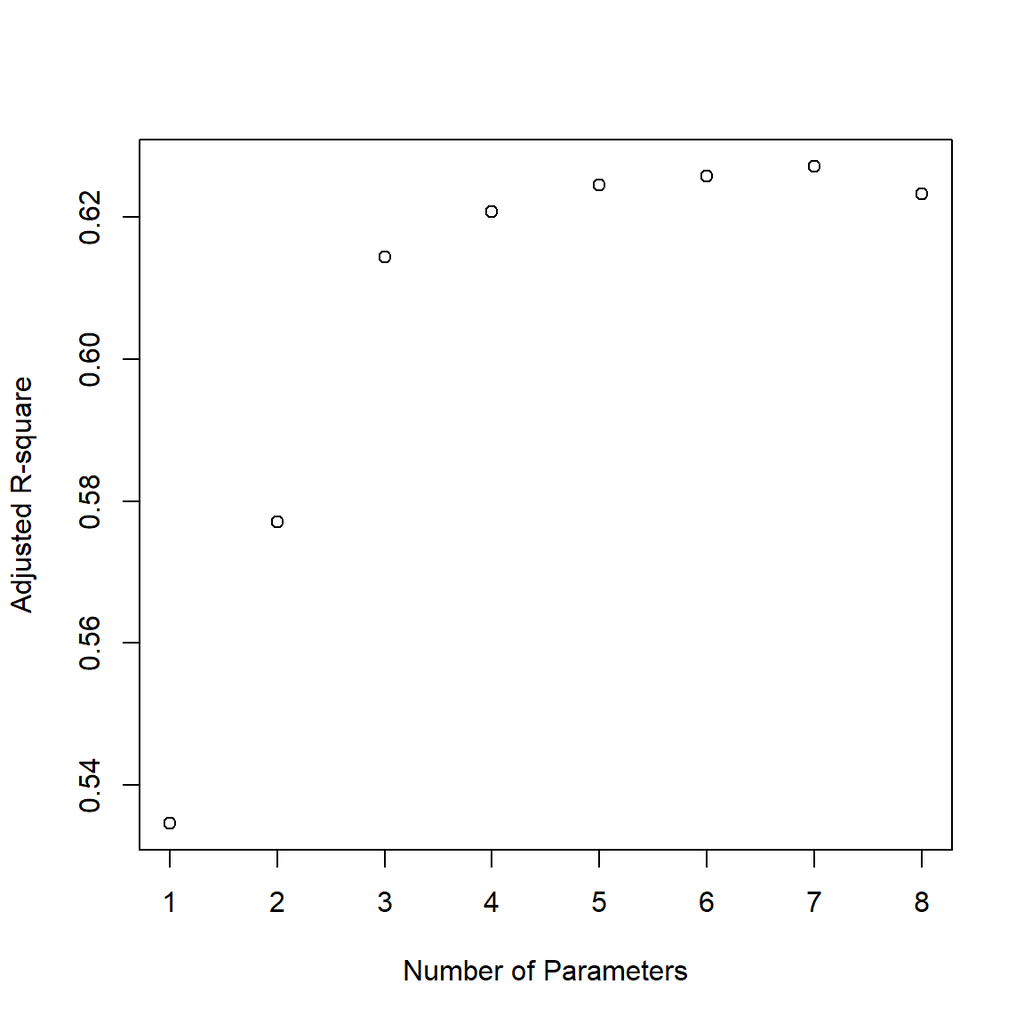

```r
plot(1:8, rs$adjr2, xlab = "Number of Parameters", ylab = "Adjusted R-square")
```

**Your answer:** Based on the Adjusted R-squared values, the best model has 7 parameters because it had the highest Adjusted R-squared value.

## (d) Mallows Cp

```r
rs #rs is summary(b)
```

```
## Subset selection object
## Call: regsubsets.formula(lpsa ~ ., data = prostate)
## 8 Variables  (and intercept)
##         Forced in Forced out
## lcavol      FALSE      FALSE
## lweight     FALSE      FALSE
## age         FALSE      FALSE
## lbph        FALSE      FALSE
## svi         FALSE      FALSE
## lcp         FALSE      FALSE
## gleason     FALSE      FALSE
## pgg45       FALSE      FALSE
## 1 subsets of each size up to 8
## Selection Algorithm: exhaustive
##          lcavol lweight age lbph svi lcp gleason pgg45
## 1  ( 1 ) "*"    " "     " " " "  " " " " " "     " "
## 2  ( 1 ) "*"    "*"     " " " "  " " " " " "     " "
## 3  ( 1 ) "*"    "*"     " " " "  "*" " " " "     " "
## 4  ( 1 ) "*"    "*"     " " "*"  "*" " " " "     " "
## 5  ( 1 ) "*"    "*"     "*" "*"  "*" " " " "     " "
## 6  ( 1 ) "*"    "*"     "*" "*"  "*" " " " "     "*"
## 7  ( 1 ) "*"    "*"     "*" "*"  "*" "*" " "     "*"
## 8  ( 1 ) "*"    "*"     "*" "*"  "*" "*" "*"     "*"
```

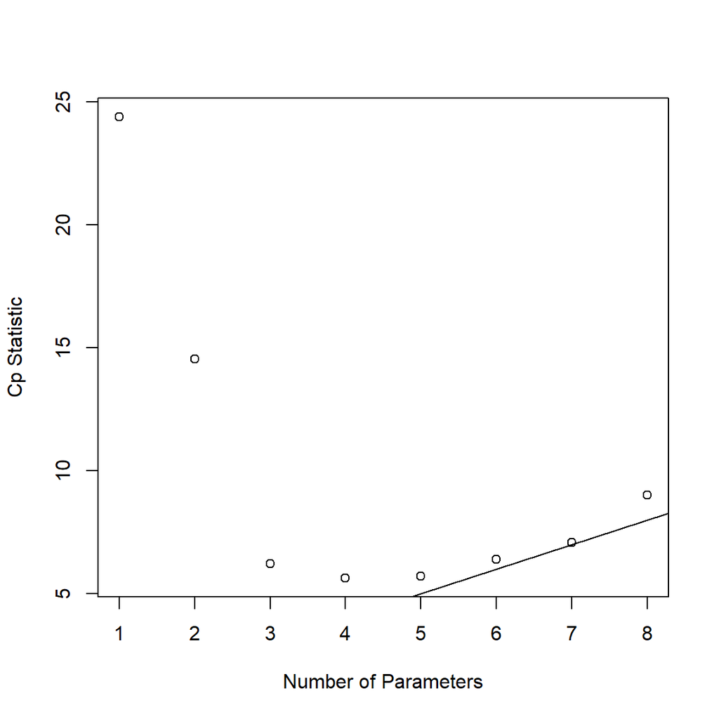

```r
plot(1:8, rs$cp, xlab = "Number of Parameters", ylab = "Cp Statistic")
abline(0,1)
```

# Chapter 10 Problem 6

### Use the seatpos data with hipcenter as the response. (a) Fit a model with all eight predictors. Comment on the effect of leg length on the response.

```r
data(seatpos, package = "faraway")
summary(seatpos)
```

```
##       Age            Weight         HtShoes            Ht
##  Min.   :19.00   Min.   :100.0   Min.   :152.8   Min.   :150.2
##  1st Qu.:22.25   1st Qu.:131.8   1st Qu.:165.7   1st Qu.:163.6
##  Median :30.00   Median :153.5   Median :171.9   Median :169.5
##  Mean   :35.26   Mean   :155.6   Mean   :171.4   Mean   :169.1
##  3rd Qu.:46.75   3rd Qu.:174.0   3rd Qu.:177.6   3rd Qu.:175.7
##  Max.   :72.00   Max.   :293.0   Max.   :201.2   Max.   :198.4
##      Seated            Arm            Thigh            Leg
##  Min.   : 79.40   Min.   :26.00   Min.   :31.00   Min.   :30.20
##  1st Qu.: 85.20   1st Qu.:29.50   1st Qu.:35.73   1st Qu.:33.80
##  Median : 89.40   Median :32.00   Median :38.55   Median :36.30
##  Mean   : 88.95   Mean   :32.22   Mean   :38.66   Mean   :36.26
##  3rd Qu.: 91.62   3rd Qu.:34.48   3rd Qu.:41.30   3rd Qu.:38.33
##  Max.   :101.60   Max.   :39.60   Max.   :45.50   Max.   :43.10
##    hipcenter
##  Min.   :-279.15
##  1st Qu.:-203.09
##  Median :-174.84
##  Mean   :-164.88
##  3rd Qu.:-119.92
##  Max.   : -30.95
```

```r
lmod <- lm(hipcenter ~ Age + Weight + HtShoes + Ht + Seated + Arm + Thigh + Leg, data = seatpos)
summary(lmod)
```

```
##
## Call:
## lm(formula = hipcenter ~ Age + Weight + HtShoes + Ht + Seated +
##     Arm + Thigh + Leg, data = seatpos)
##
## Residuals:
##     Min      1Q  Median      3Q     Max
## -73.827 -22.833  -3.678  25.017  62.337
##
## Coefficients:
##              Estimate Std. Error t value Pr(>|t|)
## (Intercept) 436.43213  166.57162   2.620   0.0138 *
## Age           0.77572    0.57033   1.360   0.1843
## Weight        0.02631    0.33097   0.080   0.9372
## HtShoes      -2.69241    9.75304  -0.276   0.7845
## Ht            0.60134   10.12987   0.059   0.9531
## Seated        0.53375    3.76189   0.142   0.8882
## Arm          -1.32807    3.90020  -0.341   0.7359
## Thigh        -1.14312    2.66002  -0.430   0.6706
## Leg          -6.43905    4.71386  -1.366   0.1824
## ---
## Signif. codes:  0 '***' 0.001 '**' 0.01 '*' 0.05 '.' 0.1 ' ' 1
##
## Residual standard error: 37.72 on 29 degrees of freedom
## Multiple R-squared:  0.6866, Adjusted R-squared:  0.6001
## F-statistic:  7.94 on 8 and 29 DF,  p-value: 1.306e-05
```

**Your answer:** For 1 unit of increase in leg length, the response hipcenter decreases by -6.43905 units.

### (b) Compute a 95% prediction interval for the mean value of the predictors.

```r
x <- model.matrix(lmod)
x0 <- apply(x, 2, mean)

#computing 95% prediction interval
predict <- predict(lmod, newdata = data.frame(t(x0)), interval="prediction")
predict
```

```
##         fit     lwr       upr
## 1 -164.8849 -243.04 -86.72972
```

**Your answer:** The 95% prediction interval is (-243.04, -86.72972).

### (c) Use AIC to select a model. Now interpret the effect of leg length and compute the prediction interval. Compare the conclusions from the two models.

```r
summary(step(lm(hipcenter ~ ., data = seatpos), direction="backward"))
```

```
## Start:  AIC=283.62
## hipcenter ~ Age + Weight + HtShoes + Ht + Seated + Arm + Thigh +
##     Leg
##
##           Df Sum of Sq   RSS    AIC
## - Ht       1      5.01 41267 281.63
## - Weight   1      8.99 41271 281.63
## - Seated   1     28.64 41290 281.65
## - HtShoes  1    108.43 41370 281.72
## - Arm      1    164.97 41427 281.78
## - Thigh    1    262.76 41525 281.87
## <none>                 41262 283.62
## - Age      1   2632.12 43894 283.97
## - Leg      1   2654.85 43917 283.99
##
## Step:  AIC=281.63
## hipcenter ~ Age + Weight + HtShoes + Seated + Arm + Thigh + Leg
##
##           Df Sum of Sq   RSS    AIC
## - Weight   1     11.10 41278 279.64
## - Seated   1     30.52 41297 279.66
## - Arm      1    160.50 41427 279.78
## - Thigh    1    269.08 41536 279.88
## - HtShoes  1    971.84 42239 280.51
## <none>                 41267 281.63
## - Leg      1   2664.65 43931 282.01
## - Age      1   2808.52 44075 282.13
##
## Step:  AIC=279.64
## hipcenter ~ Age + HtShoes + Seated + Arm + Thigh + Leg
##
##           Df Sum of Sq   RSS    AIC
## - Seated   1     35.10 41313 277.67
## - Arm      1    156.47 41434 277.78
## - Thigh    1    285.16 41563 277.90
## - HtShoes  1    975.48 42253 278.53
## <none>                 41278 279.64
## - Leg      1   2661.39 43939 280.01
## - Age      1   3011.86 44290 280.31
##
```

[output cut: 14 more lines]

```
##           Df Sum of Sq   RSS    AIC
## - Thigh    1     472.8 41958 274.26
## <none>                 41485 275.83
## - HtShoes  1    2340.7 43826 275.92
## - Age      1    3501.0 44986 276.91
## - Leg      1    3591.7 45077 276.98
##
## Step:  AIC=274.26
## hipcenter ~ Age + HtShoes + Leg
##
##           Df Sum of Sq   RSS    AIC
## <none>                 41958 274.26
## - Age      1    3108.8 45067 274.98
## - Leg      1    3476.3 45434 275.28
## - HtShoes  1    4218.6 46176 275.90
```

```
##
## Call:
## lm(formula = hipcenter ~ Age + HtShoes + Leg, data = seatpos)
##
## Residuals:
##     Min      1Q  Median      3Q     Max
## -79.269 -22.770  -4.342  21.853  60.907
##
## Coefficients:
##             Estimate Std. Error t value Pr(>|t|)
## (Intercept) 456.2137   102.8078   4.438 9.09e-05 ***
## Age           0.5998     0.3779   1.587   0.1217
## HtShoes      -2.3023     1.2452  -1.849   0.0732 .
## Leg          -6.8297     4.0693  -1.678   0.1024
## ---
## Signif. codes:  0 '***' 0.001 '**' 0.01 '*' 0.05 '.' 0.1 ' ' 1
##
## Residual standard error: 35.13 on 34 degrees of freedom
## Multiple R-squared:  0.6813, Adjusted R-squared:  0.6531
## F-statistic: 24.22 on 3 and 34 DF,  p-value: 1.437e-08
```

**Your answer:** For every 1 unit of increase in leg length, the response hipcenter decreases by -6.8297 units. Compared to the previous model which had for 1 unit of increase in leg length, the response hipcenter decreases by -6.43905 units. Seems like this AIC selected model has a slightly steeper negative slope compared to that of the previous model.

```r
lmod <- lm(hipcenter ~ Age + HtShoes + Leg, data = seatpos)

x <- model.matrix(lmod)
x0 <- apply(x, 2, mean)

#computing 95% prediction interval
predict <- predict(lmod, newdata = data.frame(t(x0)), interval="prediction")
predict
```

```
##         fit      lwr       upr
## 1 -164.8849 -237.209 -92.56072
```

**Your answer:** The 95% prediction interval is (-237.209, -92.56072). Compared to the 95% prediction interval of the previous model which is (-243.04, -86.72972). It seems like the 95% prediction interval is a little narrower than that of the previous model.

# Chapter 11 Problem 1

### Using the seatpos data, perform a PCR analysis with hipcenter as the response and HtShoes, Ht, Seated, Arm, Thigh and Leg as predictors. Select an appropriate number of components and give an interpretation to those you choose. Add Age and Weight as predictors and repeat the analysis. Use both models to predict the response for predictors taking these values:

Data from textbook: Age <- 64.800 Weight <- 263.700 HtShoes <- 181.080 Ht <- 178.560 Seated <- 91.440 Arm <- 35.640 Thigh <- 40.950 Leg <- 38.790

```r
seatpos_pca <- prcomp(seatpos[,3:8])
seatpos_pca
```

```
## Standard deviations (1, .., p=6):
## [1] 17.1573126  2.8968910  2.1190723  1.5641245  1.2250216  0.4621792
##
## Rotation (n x k) = (6 x 6):
##                PC1         PC2         PC3         PC4        PC5          PC6
## HtShoes -0.6488633 -0.10486441 -0.02068172 -0.15880361 -0.2394122  0.696430410
## Ht      -0.6505360 -0.05847157  0.02690768 -0.18021013 -0.1723989 -0.714466871
## Seated  -0.2682047 -0.38475765  0.25665698  0.75373956  0.3821288  0.003037444
## Arm     -0.1505350  0.46295882 -0.71508938  0.48679093 -0.1192321 -0.021767388
## Thigh   -0.1682567  0.78851959  0.56019393  0.06512031  0.1707327  0.052143943
## Leg     -0.1813131  0.03810613 -0.32833729 -0.36465920  0.8506304  0.036328203
```

```r
summary(seatpos_pca)
```

```
## Importance of components:
##                            PC1     PC2     PC3     PC4     PC5     PC6
## Standard deviation     17.1573 2.89689 2.11907 1.56412 1.22502 0.46218
## Proportion of Variance  0.9453 0.02695 0.01442 0.00786 0.00482 0.00069
## Cumulative Proportion   0.9453 0.97222 0.98664 0.99450 0.99931 1.00000
```

**Your answer:** From this summary, it seems like the first principal component explains 94.53% of the variation in the data whereas the other components don’t explain a lot more about the variance. So, we could use only the first PC.

But to double check, we plot the standard deviations of the principal components:

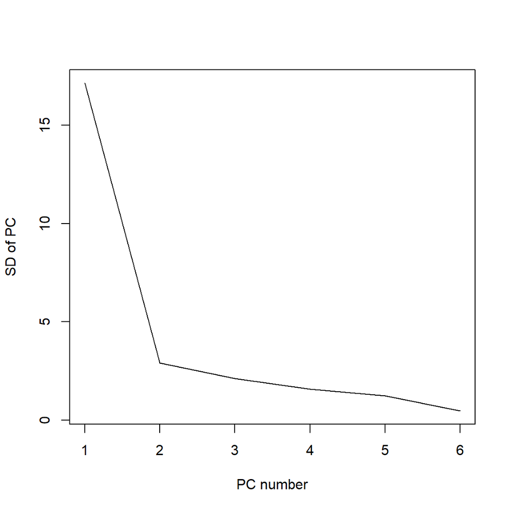

```r
#sdev and SD both represent standard deviation
plot(seatpos_pca$sdev,type="l",ylab="SD of PC", xlab="PC number")
```

**Your answer:** The “elbow” is at 2 which means that we should use only the first PC based on this plot, as well.

Now predict the response for predictors taking these values:

```r
#note to self: use pcr function to do principal component regression and not lm (even though it looks similar)

#install.packages("pls")
library(pls)
pcr_seatpos <- pcr(hipcenter ~ HtShoes + Ht + Seated + Arm + Thigh + Leg, data = seatpos, ncomp = 1) #ncomp is 1 because we're using only 1 PC
summary(pcr_seatpos)
```

```
## Data:    X dimension: 38 6
##  Y dimension: 38 1
## Fit method: svdpc
## Number of components considered: 1
## TRAINING: % variance explained
##            1 comps
## X            94.53
## hipcenter    63.80
```

```r
Age <- 64.800
Weight <- 263.700
HtShoes <- 181.080
Ht <- 178.560
Seated <- 91.440
Arm <- 35.640
Thigh <- 40.950
Leg <- 38.790
```

```r
x0 <- c(Age, Weight, HtShoes, Ht, Seated, Arm, Thigh, Leg)
predict(pcr_seatpos, newdata=data.frame(t(x0)), interval="predict")
```

```
## , , 1 comps
##
##   hipcenter
## 1 -205.0924
```

**Your answer:** The predicted value for the response with one principal component is -205.0924.

Adding Age and Weight and doing the PCR analysis again:

```r
seatpos_pca <- prcomp(seatpos[,1:8])
seatpos_pca
```

```
## Standard deviations (1, .., p=8):
## [1] 38.6976593 15.6583950  8.4329629  2.6044941  1.8762544  1.4685986  1.2008529
## [8]  0.4440546
##
## Rotation (n x k) = (8 x 8):
##                 PC1          PC2        PC3         PC4          PC5
## Age     -0.02656516 -0.973286219 -0.1993345  0.07358807 -0.061513592
## Weight  -0.92053301 -0.055430205  0.3855962 -0.02766099 -0.008009736
## HtShoes -0.25254069  0.133886012 -0.5807696  0.14807810  0.019193825
## Ht      -0.25317632  0.141520720 -0.5773155  0.06234507  0.033276939
## Seated  -0.10445187  0.085258885 -0.2152331  0.34707440 -0.550865336
## Arm     -0.06360299 -0.059300292 -0.1585311 -0.17479834  0.597921590
## Thigh   -0.06177741 -0.001172272 -0.2173435 -0.90376485 -0.318988403
## Leg     -0.07256890  0.030014565 -0.1493290  0.01412876  0.481621965
##                  PC6          PC7          PC8
## Age      0.048324829  0.024698396  0.011381619
## Weight   0.002826413 -0.004297615 -0.002508137
## HtShoes  0.218015623 -0.184489007 -0.690754566
## Ht       0.186899554 -0.155203232  0.720115741
## Seated  -0.631124887  0.336498173  0.005703586
## Arm     -0.708809326 -0.275978866 -0.025813714
## Thigh   -0.051116030  0.157142748 -0.055612712
## Leg      0.108868432  0.852735648 -0.019077860
```

```r
summary(seatpos_pca)
```

```
## Importance of components:
##                            PC1     PC2     PC3     PC4     PC5     PC6     PC7
## Standard deviation     38.6977 15.6584 8.43296 2.60449 1.87625 1.46860 1.20085
## Proportion of Variance  0.8193  0.1341 0.03891 0.00371 0.00193 0.00118 0.00079
## Cumulative Proportion   0.8193  0.9534 0.99229 0.99600 0.99792 0.99910 0.99989
##                            PC8
## Standard deviation     0.44405
## Proportion of Variance 0.00011
## Cumulative Proportion  1.00000
```

**Your answer:** From this summary, it seems like the first 3 principal components explain 99.23% of the variation in the data whereas the other components don’t explain a lot more about the variance. So, we could use only the first three PC’s.

But to double check, we plot the standard deviations of the principal components:

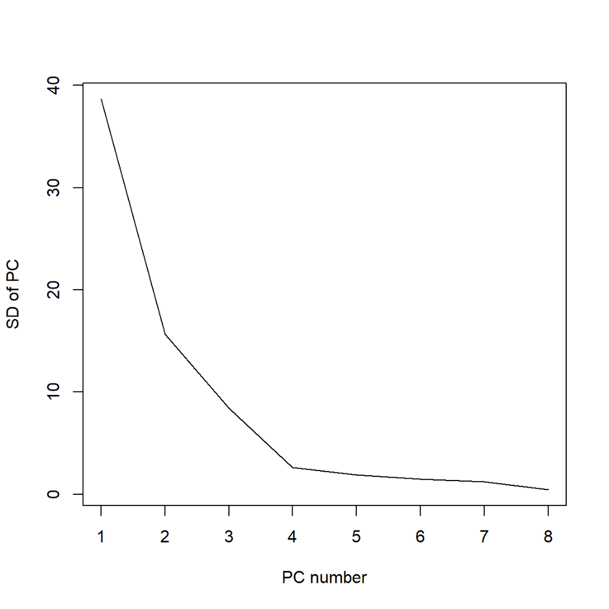

```r
#sdev and SD both represent standard deviation
plot(seatpos_pca$sdev,type="l",ylab="SD of PC", xlab="PC number")
```

**Your answer:** The “elbow” is at 4 which means that we should use only the first 3 PC’s based on this plot, as well.

Now predict the response for predictors taking these values:

```r
library(pls)
pcr_seatpos <- pcr(hipcenter ~ Age + Weight + HtShoes + Ht + Seated + Arm + Thigh + Leg, data = seatpos, ncomp = 3) #ncomp is 3 because we're using 3 PC's
summary(pcr_seatpos)
```

```
## Data:    X dimension: 38 8
##  Y dimension: 38 1
## Fit method: svdpc
## Number of components considered: 3
## TRAINING: % variance explained
##            1 comps  2 comps  3 comps
## X            81.92    95.34    99.23
## hipcenter    46.36    54.69    65.99
```

```r
predict(pcr_seatpos, newdata=data.frame(t(x0)), interval="predict") #x0 is the data from the textbook
```

```
## , , 1 comps
##
##   hipcenter
## 1 -276.0396
##
## , , 2 comps
##
##   hipcenter
## 1 -240.8368
##
## , , 3 comps
##
##   hipcenter
## 1 -186.7917
```

**Your answer:** The predicted value for the response with 1 principal component is -276.0396. The predicted value for the response with 2 principal components is -240.8368. And the predicted value for the response with 3 principal components is -186.7917.

# Chapter 11 Problem 6 (a-d)

### The dataset kanga contains data on the skulls of historical kangaroo specimens. (a) Compute a PCA on the 18 skull measurements. You will need to exclude observations with missing values. What percentage of variation is explained by the first principal component?

```r
library(faraway)
head(kanga) #looking for NA values
```

```
##     species  sex basilar.length occipitonasal.length palate.length palate.width
## 1 giganteus Male           1312                 1445           882           NA
## 2 giganteus Male           1439                 1503           985          230
## 3 giganteus Male           1378                 1464           934           NA
## 4 giganteus Male           1315                 1367           895          230
## 5 giganteus Male           1413                 1500           969           NA
## 6 giganteus Male           1090                 1195           740           NA
##   nasal.length nasal.width squamosal.depth lacrymal.width zygomatic.width
## 1          609         241             180            394             782
## 2          629         222             150            416             824
## 3          620         233             135            403             778
## 4          564         207             158            394             801
## 5          645         247             161            426             823
## 6          493         189             122            350             673
##   orbital.width .rostral.width occipital.depth crest.width foramina.length
## 1           249            227             531         153              88
## 2           233            248             632         141             100
## 3           244            240             575         144             107
## 4           224            242             568         116              79
## 5           241            252             607         120              99
## 6           234            185             462         188              90
##   mandible.length mandible.width mandible.depth ramus.height
## 1            1086            131            179          591
## 2            1158            148            181          643
## 3            1131            116            169          610
## 4            1090            132            189          594
## 5            1175            131            197          654
## 6             901            101            138          476
```

```r
kanga_without_NA <- na.omit(kanga)
kanga_without_NA_pca <- prcomp(kanga_without_NA[,-c(1,2)]) #-c(1,2) in the column spot of [] removes col 1 and 2. They need to be removed because they have non-numeric values in them.

summary(kanga_without_NA_pca)
```

```
## Importance of components:
##                             PC1      PC2      PC3      PC4      PC5      PC6
## Standard deviation     288.0382 69.51124 30.74720 27.85580 21.73015 19.42356
## Proportion of Variance   0.9003  0.05243  0.01026  0.00842  0.00512  0.00409
## Cumulative Proportion    0.9003  0.95269  0.96295  0.97136  0.97649  0.98058
##                             PC7     PC8      PC9     PC10     PC11     PC12
## Standard deviation     17.28247 16.6247 14.52310 13.98826 12.35253 12.07402
## Proportion of Variance  0.00324  0.0030  0.00229  0.00212  0.00166  0.00158
## Cumulative Proportion   0.98382  0.9868  0.98911  0.99123  0.99289  0.99447
##                            PC13     PC14    PC15    PC16    PC17    PC18
## Standard deviation     11.94245 10.82939 10.0735 8.46081 7.16825 5.01246
## Proportion of Variance  0.00155  0.00127  0.0011 0.00078 0.00056 0.00027
## Cumulative Proportion   0.99602  0.99729  0.9984 0.99917 0.99973 1.00000
```

**Your answer:** The percentage of variation explained by the first PC is 90.03%.

### (b) Provide the loadings for the first principal component. What variables are prominent?

```r
#The loadings can be found in the rotation matrix ($rotation)
kanga_without_NA_pca$rotation[,1] #[,1] means 1st col and that is PC1
```

```
##       basilar.length occipitonasal.length        palate.length
##          0.484068280          0.456296136          0.366214204
##         palate.width         nasal.length          nasal.width
##          0.084357568          0.248098913          0.074647492
##      squamosal.depth       lacrymal.width      zygomatic.width
##          0.063661339          0.118936859          0.206697648
##        orbital.width       .rostral.width      occipital.depth
##          0.014288869          0.106458931          0.178177037
##          crest.width      foramina.length      mandible.length
##         -0.081968043          0.009941189          0.435981938
##       mandible.width       mandible.depth         ramus.height
##          0.029996792          0.058322138          0.209071437
```

### (c) Repeat the PCA but with the variables all scaled to the same standard deviation. How do the percentage of variation explained and the first principal component differ from those found in the previous PCA?

```r
pca_scaled <- prcomp(kanga_without_NA[,-c(1,2)], center=TRUE, scale=TRUE)#before in part a center=TRUE and scale=FALSE (which is the default)
summary(pca_scaled)
```

```
## Importance of components:
##                           PC1     PC2    PC3    PC4    PC5     PC6     PC7
## Standard deviation     3.5321 1.30672 1.1006 0.8443 0.6463 0.56426 0.51064
## Proportion of Variance 0.6931 0.09486 0.0673 0.0396 0.0232 0.01769 0.01449
## Cumulative Proportion  0.6931 0.78796 0.8553 0.8949 0.9181 0.93575 0.95024
##                            PC8     PC9   PC10    PC11   PC12    PC13    PC14
## Standard deviation     0.45185 0.43863 0.3723 0.30491 0.2815 0.24345 0.22317
## Proportion of Variance 0.01134 0.01069 0.0077 0.00517 0.0044 0.00329 0.00277
## Cumulative Proportion  0.96158 0.97227 0.9800 0.98514 0.9895 0.99283 0.99560
##                           PC15    PC16    PC17    PC18
## Standard deviation     0.18583 0.15031 0.11849 0.08949
## Proportion of Variance 0.00192 0.00126 0.00078 0.00044
## Cumulative Proportion  0.99752 0.99878 0.99956 1.00000
```

**Your answer:** The percentage of variation explained is different because the variance explained by the first PC for this PCA is 69.31% instead of 90.03%. Also, it seems like this scaled PCA will need more PC’s than the previous one because it takes more PC’s to explain a lot of the variation compared to the previous one.

Loadings for the first principal component:

```r
pca_scaled$rotation[,1] #[,1] means 1st col and that is PC1
```

```
##       basilar.length occipitonasal.length        palate.length
##           0.27663672           0.26669384           0.27537523
##         palate.width         nasal.length          nasal.width
##           0.23411769           0.23005097           0.22715310
##      squamosal.depth       lacrymal.width      zygomatic.width
##           0.23883025           0.26636218           0.25791527
##        orbital.width       .rostral.width      occipital.depth
##           0.07450619           0.25779463           0.27101120
##          crest.width      foramina.length      mandible.length
##          -0.16457085           0.05854653           0.27876043
##       mandible.width       mandible.depth         ramus.height
##           0.20978820           0.23957437           0.25998273
```

### (d) Give an interpretation of the second principal component.

Loadings for the second principal component:

```r
pca_scaled$rotation[,2] #[,2] means 2nd col and that is PC2
```

```
##       basilar.length occipitonasal.length        palate.length
##           0.01273084          -0.17029778          -0.05512591
##         palate.width         nasal.length          nasal.width
##          -0.07753121          -0.36664683          -0.29975109
##      squamosal.depth       lacrymal.width      zygomatic.width
##           0.16343649          -0.01336390           0.24874191
##        orbital.width       .rostral.width      occipital.depth
##           0.03368915           0.01395540           0.02104476
##          crest.width      foramina.length      mandible.length
##           0.41336447          -0.45016270           0.02390240
##       mandible.width       mandible.depth         ramus.height
##           0.38952086           0.26394090           0.22691748
```